# Er det høyde som bestemmer inntekt?

Av Ann Elisabeth og Heidi Marie Rolfsnes

Innledning I denne oppgaven vil vi kikke nærmere om høyde har noe å si på inntekten man får. Utgangspunket til denne oppgaven bygger på et datasett vi har fått utdelt hentet fra National Longitudial study, som er gjennomført på vegne av U.S Bureau of Labor statistics.

Oppsummerings statistikker.

Ut fra undersøkelsen kan vi se et utvalg på 7006 personer, der 3402 er menn og 3604 er kvinner. aldersspennet i utvalget er fra 47 til 56 år, der medianen alder er 51 år og gjennomsnittsalderen er 51,33 år. Inntektene til de utvalgte går fra 0 USD til 343830 USD, her kan vi også se at medianen er 29589,50 USD mens gjennomsnittet er på 41203,90 USD. vis vi ser på høyden så er den laveste personen 52 inch og den høyeste er 84 Inch.

Er det høyde som bestemmer inntekt?

# Teori

# Statistikk

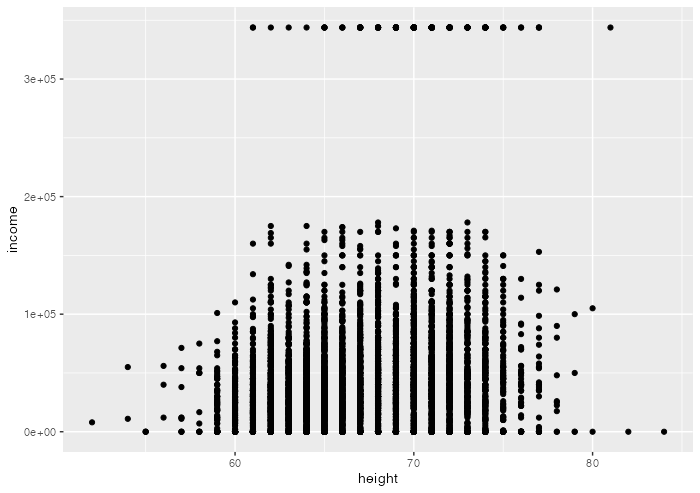

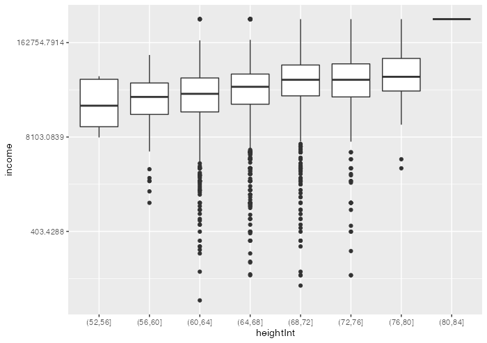

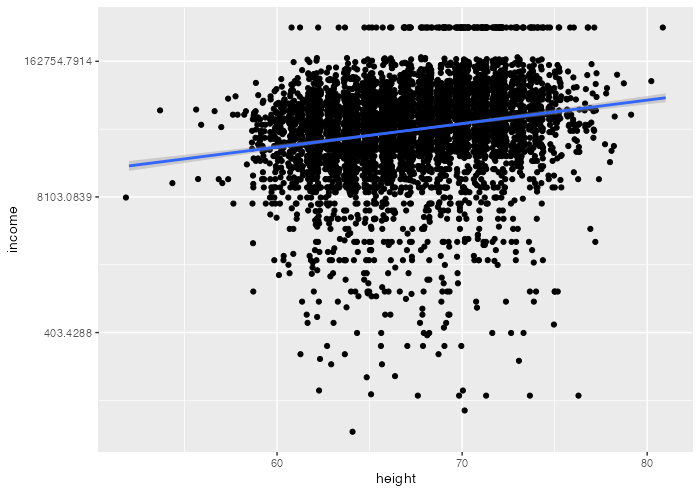

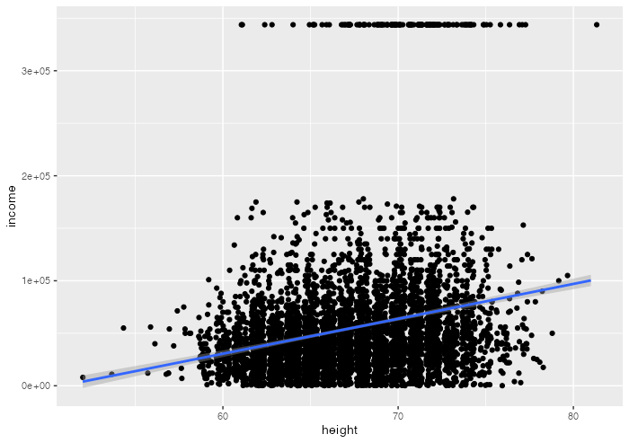

Hvor mye tjener vi pr ekstra inch?

En ekstra inxh (2,72cm) gir oss $2982 ekstra i inntekt pr år.

Er det mer til historien?